# Simulation and estimation from conditional copula models

# Visualization of the conditional dependence

First, we do a scatterplot of $(X_1, X_2)$ where the color of the points is determined by the value of $X_3$.

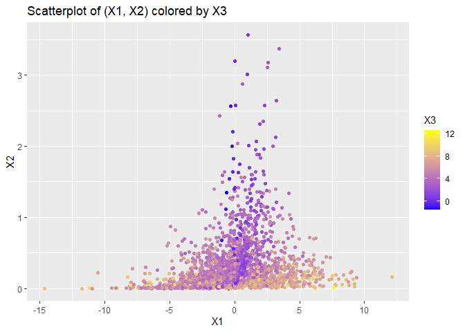

```r
ggplot() + geom_point(aes(x=X1, y=X2, color = X3)) +
  scale_color_gradient(low="blue", high="yellow") +
  ggtitle("Scatterplot of (X1, X2) colored by X3")
```

We see that the blue points seem quite dependent whereas the yellow points seem less dependent. Let us confirm this by plotting the two subsets separately.

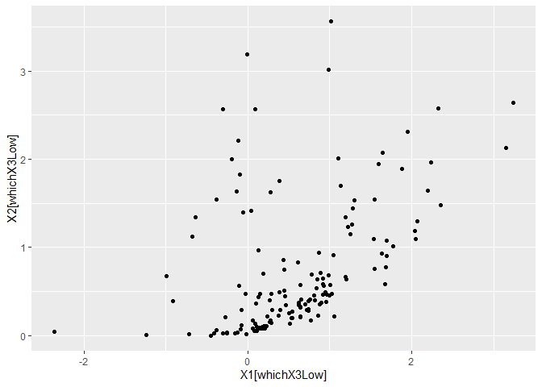

```r
whichX3Low = which(X3 <= 2)
whichX3High = which(X3 > 8)
ggplot() + geom_point(aes(x=X1[whichX3Low], y=X2[whichX3Low]))
```

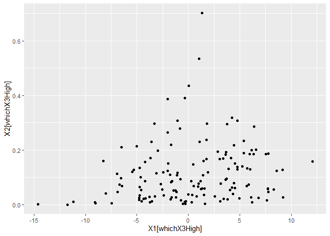

```r
ggplot() + geom_point(aes(x=X1[whichX3High], y=X2[whichX3High]))
```

It seems that on the first plot, the dependence is quite high between $X_1$ and $X_2$, while it is much smaller in the second plot. This will be confirmed in the next section.

# Parametric estimation of the conditional copula

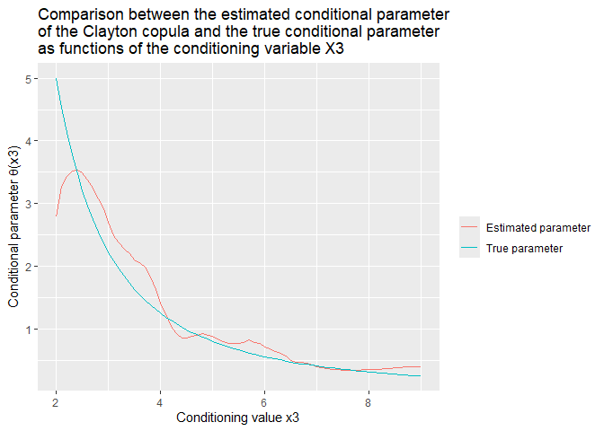

```r
newX3 = seq(2, 9, by = 0.1)

vecEstimatedThetas = estimateParCondCopula(
  observedX1 = X1, observedX2 = X2, observedX3 = X3, newX3 = newX3, family = 3, h = 0.08)

trueCKT12_3 = ckt12_3_fun(newX3)

comparison = data.frame(
  x3    = rep(newX3, 2),
  param = c(vecEstimatedThetas , BiCopTau2Par(copFamily12_3, trueCKT12_3)),
  CKT   = c(BiCopPar2Tau(copFamily12_3, vecEstimatedThetas) , trueCKT12_3),
  id    = rep(1:2,each=length(newX3)))

ggplot(data = comparison) +
  geom_line(aes(x = x3, y = param, color = as.factor(id), group = as.factor(id))) +
  scale_color_discrete(labels = c("Estimated parameter", "True parameter"), name="") +
  xlab("Conditioning value x3") +
  ylab(expression(paste("Conditional parameter ",theta,"(x3)"))) +
  ggtitle(paste0("Comparison between the estimated conditional parameter\n",
                 "of the Clayton copula and the true conditional parameter\n",
                 "as functions of the conditioning variable X3"))
```

Since there exists a bijection between the parameter of the conditional copula and the associated Kendall’s tau, this can also give us an estimator of the conditional Kendall’s tau. In the next graph, we compare this estimator with the true value of the conditional Kendall’s tau.

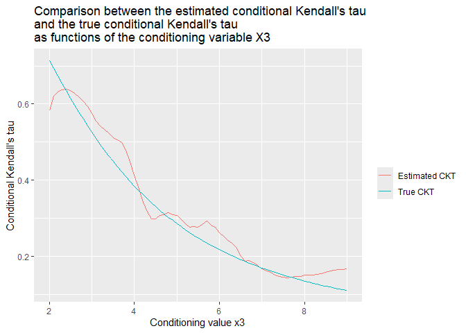

```r
ggplot(data = comparison, aes(x = x3, y = CKT, color = as.factor(id), group = as.factor(id))) +
  geom_line() +
  scale_color_discrete(labels = c("Estimated CKT","True CKT"), name="") +
  xlab("Conditioning value x3") +
  ylab("Conditional Kendall's tau") +
  ggtitle(paste0("Comparison between the estimated conditional Kendall's tau\n",
                 "and the true conditional Kendall's tau\n",
                 "as functions of the conditioning variable X3"))
```